# Auckland Carpark Availability

## Overview

**Last updated:** 2025-10-09 20:12:58 NZDT

This dashboard summarises the latest availability for selected Auckland carparks and trends over time. Data is collected hourly by an automated pipeline and rendered here.

> **Note (Downtown carpark):** Downtown is no longer operated by Auckland Transport (now operated by Precinct Properties). AT availability data for Downtown may be inaccurate. Historic data is retained for reference only.

**Carparks tracked:** 5  
**Available spaces (now):** 2,773  
**Mean occupancy (where capacity known):** 34.4%

## Latest snapshot

| Carpark | Parking option | Available spaces | Total spaces | Occupancy |
| --- | --- | --- | --- | --- |
| Civic | Short-term | 659 | 928 | 29% |
| Downtown | Short-term | 776 | 1944 | 60.1% |
| Ronwood | Short-term | 518 | 678 | 23.6% |
| Toka Puia | Short-term | 390 | 420 | 7.1% |
| Victoria Street | Short-term | 430 | 895 | 52% |

## Occupancy trend

How full each carpark is over time? This view uses daily averages plus a smoothed curve to reveal longer-term patterns. 📊

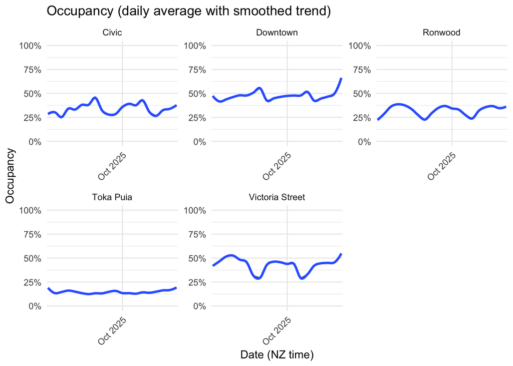

Which days are busiest vs quietest? This weekday view reveals recurring patterns🚗.

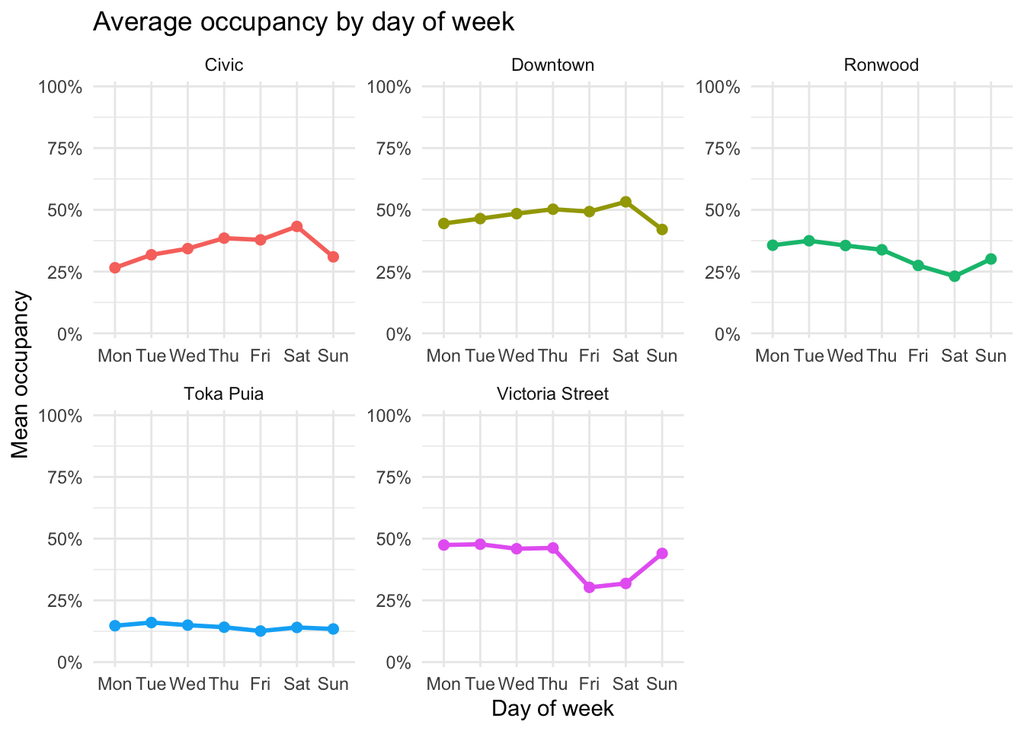

## Insights and Patterns

### 🏆 Popularity ranking (overall)

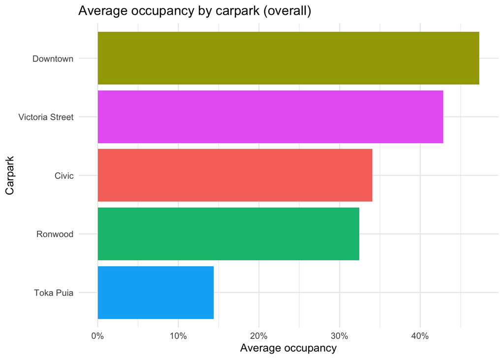

### 🗓️ Average occupancy by day of week

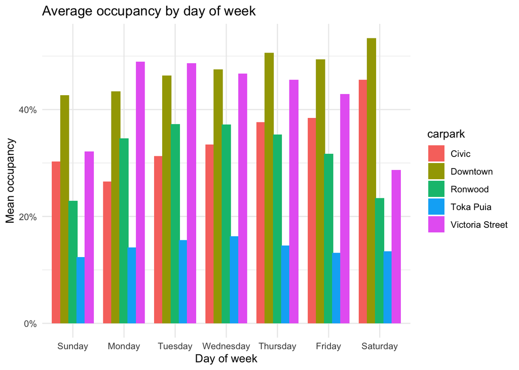

### ⏰ Hourly occupancy pattern

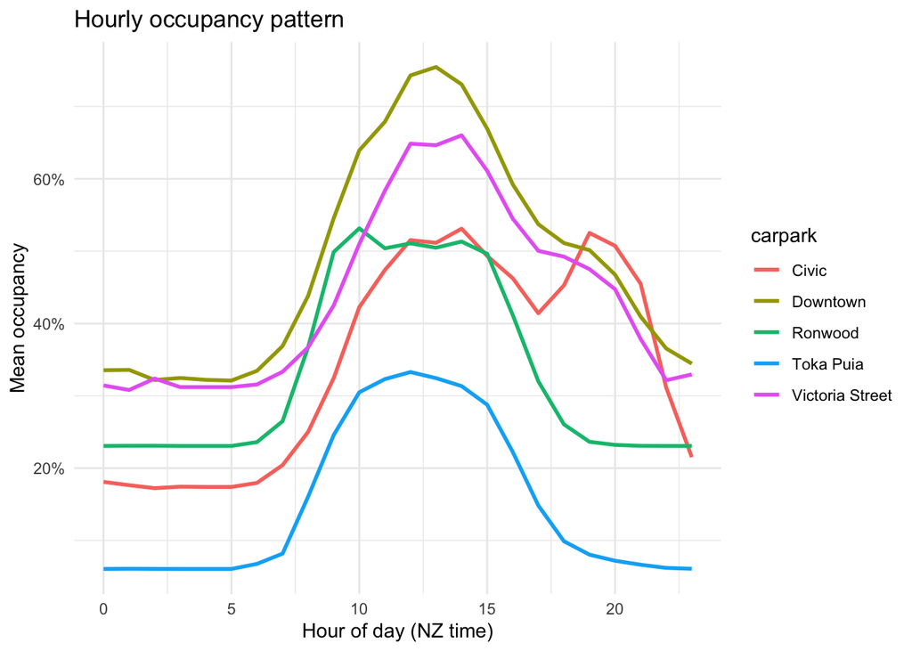

### 🔥 Heatmap: weekday × hour

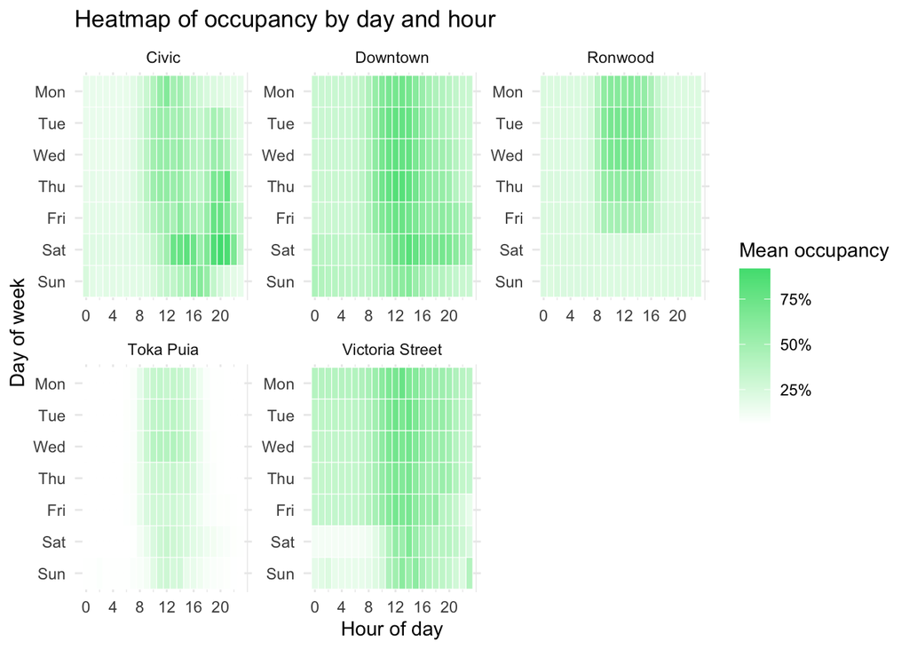

### 📈 Weekly occupancy trend over time

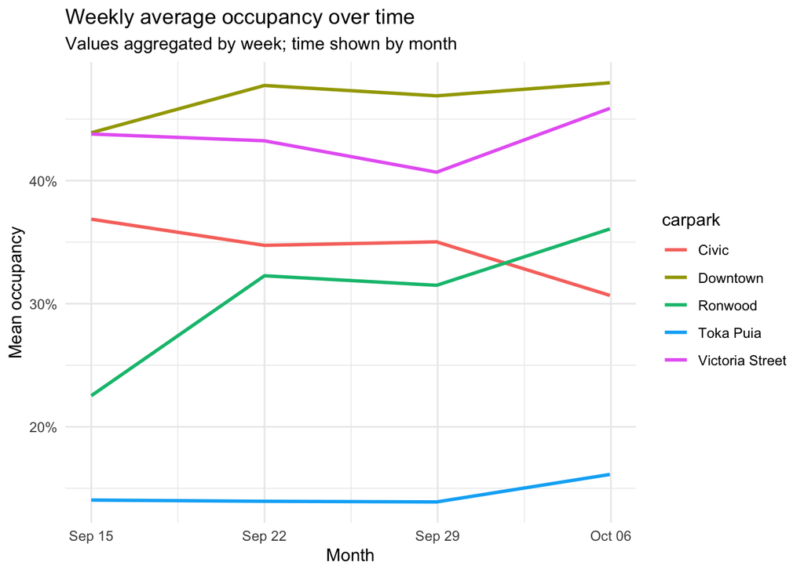

## 🎓 Credits and reflections

This dashboard was inspired by my **STATS 220 (University of Auckland, Semester 1 2025)** course, where I learnt R and R Markdown for data collection, wrangling, and visualisation.

In the course, **Anna Fergusson** introduced an Auckland carpark availability endpoint during a lecture. I found it really interesting, so I extended the idea into this small tool: an automated pipeline that collects the data hourly and produces this report.

Credit: [Anna Fergusson](https://annafergusson.online) 🙌

### 🔍 What I found interesting

Even with a small dataset, you can spot real patterns, for example:

- Some carparks are consistently busier than others (likely influenced by **location** and nearby activities).
- Day-of-week patterns could reflect **work-from-home** behaviour.
- Civic sometimes shows an occupancy lift around **7–8pm**, which might align with nearby **events / movies** and evening visits.

### 🚀 Next steps

There are still lots of improvements I could make (e.g., better annotations, handling missing capacity, and adding richer context like events or weather), but this is a milestone for me — and I’m happy to share it with anyone who’s curious. Thanks to everyone who’s taken the time to look at it. **Happy coding!** 💻🎉